# Project proposal

Loki

2024-08-25

```r
# Load in all libraries
library(tidyverse)
library(here)      # directory referencing
library(readxl)    # reading Excel files
library(janitor)   # data cleaning
library(stringr)   # string manimpuation
library(tidyr)     # new tidy functions
```

# Feasibility Analysis

## 1. Research Questions:

Question 1: Is there a dependence of grains and cereals intake (serves/g) on whether individuals have diabetes mellitus? Question 2: What is the correlation between grains and cereals intake (serves/g) and fasting plasma glucose? Question 3: What is the correlation between grains and cereals intake (serves/g) and HbA1c?

```r
raw_bp <- read.csv(here("ZIPallFiles","AHSnpa11bp.csv"), header=TRUE)
raw_bb <- read.csv(here("ZIPallFiles","AHSnpa11bb.csv"), header=TRUE)
```

```r
# Subset raw_bp to include relevant variables
selected_bp <- raw_bp %>%
  select(ABSHID, ABSPID, LEVELP, GRAINS1N, GRAINS2N, DIABBC)

# View the first few rows to ensure the subset is correct
head(selected_bp)
```

```
##          ABSHID         ABSPID LEVELP GRAINS1N GRAINS2N DIABBC
## 1 NPA11B1000001 NPA11B10000011      3  4.08403  8.14560      5
## 2 NPA11B1000002 NPA11B10000021      3  4.85267  2.04267      5
## 3 NPA11B1000003 NPA11B10000031      3  0.46857  4.43751      5
## 4 NPA11B1000004 NPA11B10000041      3  2.76307  1.92935      5
## 5 NPA11B1000005 NPA11B10000051      3  3.55843  1.76471      1
## 6 NPA11B1000005 NPA11B10000052      3  1.35255  0.40179      5
```

```r
# Subset raw_bb to include relevant variables
selected_bb <- raw_bb %>%
  select(ABSHID, ABSPID, ABSBID, GLUCFPD, GLUCFREB, HBA1MREB, HBA1PREB, DIABFPGE, DIABPRVE)

# View the first few rows to ensure the subset is correct
head(selected_bb)
```

```
##          ABSHID         ABSPID ABSBID GLUCFPD GLUCFREB HBA1MREB HBA1PREB
## 1 NPA11B1000001 NPA11B10000011      1       1        1        8        8
## 2 NPA11B1000002 NPA11B10000021      1       1        4        3        3
## 3 NPA11B1000003 NPA11B10000031      2       1        2        2        3
## 4 NPA11B1000004 NPA11B10000041      1       1        3        1        2
## 5 NPA11B1000005 NPA11B10000051      2       0       97        7        7
## 6 NPA11B1000005 NPA11B10000052      4       0       97        7        7
##   DIABFPGE DIABPRVE
## 1        3        8
## 2        3        3
## 3        3        3
## 4        3        3
## 5        0        0
## 6        0        0
```

```r
# Merge the datasets on ABSHID and ABSPID
merged_data <- merge(selected_bp, selected_bb, by = c("ABSHID", "ABSPID"))

# View the first few rows of the merged dataset
head(merged_data)
```

```
##          ABSHID         ABSPID LEVELP GRAINS1N GRAINS2N DIABBC ABSBID GLUCFPD
## 1 NPA11B1000001 NPA11B10000011      3  4.08403  8.14560      5      1       1
## 2 NPA11B1000002 NPA11B10000021      3  4.85267  2.04267      5      1       1
## 3 NPA11B1000003 NPA11B10000031      3  0.46857  4.43751      5      2       1
## 4 NPA11B1000004 NPA11B10000041      3  2.76307  1.92935      5      1       1
## 5 NPA11B1000005 NPA11B10000051      3  3.55843  1.76471      1      2       0
## 6 NPA11B1000005 NPA11B10000052      3  1.35255  0.40179      5      4       0
##   GLUCFREB HBA1MREB HBA1PREB DIABFPGE DIABPRVE
## 1        1        8        8        3        8
## 2        4        3        3        3        3
## 3        2        2        3        3        3
## 4        3        1        2        3        3
## 5       97        7        7        0        0
## 6       97        7        7        0        0
```

```r
# Create a data frame with variable names and their meanings
variable_info <- data.frame(
  Variable = c("GRAINS1N", "GRAINS2N", "DIABBC", "GLUCFPD", "GLUCFREB",
               "HBA1MREB", "HBA1PREB", "DIABFPGE", "DIABPRVE", "ABSHID",
               "ABSPID", "LEVELP", "ABSBID"),
  Description = c("Grains and cereals intake (serves) Day 1",
                  "Grains and cereals intake (serves) Day 2",
                  "Diabetes mellitus status",
                  "Fasting plasma glucose status (mmol/L)",
                  "Fasting plasma glucose - ranged (mmol/L)",
                  "HbA1c - ranged (mmol/mol)",
                  "HbA1c - ranged (%)",
                  "Diabetes prevalence - fasting plasma glucose (mmol/L)",
                  "Diabetes prevalence - HbA1c (%)",
                  "Household identifier",
                  "Selected person identifier",
                  "Record level identifier for Persons",
                  "Biomedical record identifier")
)

# View the summary table
print(variable_info)
```

```
##    Variable                                           Description
## 1  GRAINS1N              Grains and cereals intake (serves) Day 1
## 2  GRAINS2N              Grains and cereals intake (serves) Day 2
## 3    DIABBC                              Diabetes mellitus status
## 4   GLUCFPD                Fasting plasma glucose status (mmol/L)
## 5  GLUCFREB              Fasting plasma glucose - ranged (mmol/L)
## 6  HBA1MREB                             HbA1c - ranged (mmol/mol)
## 7  HBA1PREB                                    HbA1c - ranged (%)
## 8  DIABFPGE Diabetes prevalence - fasting plasma glucose (mmol/L)
## 9  DIABPRVE                       Diabetes prevalence - HbA1c (%)
## 10   ABSHID                                  Household identifier
## 11   ABSPID                            Selected person identifier
## 12   LEVELP                   Record level identifier for Persons
## 13   ABSBID                          Biomedical record identifier
```

## 3. Predictor Variables:

Primary Predictor: GRAINS1N and GRAINS2N (Grains and cereals intake in serves, Day 1 and Day 2).

## 4. Potential Confounding Variables:

```r
#Find Demographic Variables
```

Demographic Variables: Age, Sex, BMI (AGEC, SEX, BMISC). Other Dietary Factors: Total calorie intake, intake of other macronutrients or micronutrients, physical activity levels. Biomarkers: Cholesterol levels, blood pressure.

# 6. Initial Analyses

```r
#Chi-Square Test for Dependence (Question 1):
table_data <- table(merged_data$DIABBC, merged_data$GRAINS1N)
chisq.test(table_data)
```

```
##
##  Pearson's Chi-squared test
##
## data:  table_data
## X-squared = 18514, df = 19398, p-value = 1
```

```r
#Correlation Analysis (Questions 2 & 3)
cor(merged_data$GRAINS1N, merged_data$GLUCFPD, use = "complete.obs")
```

```
## [1] 0.0282811
```

```r
cor(merged_data$GRAINS1N, merged_data$HBA1MREB, use = "complete.obs")
```

```
## [1] -0.037637
```

# 7. Visualization

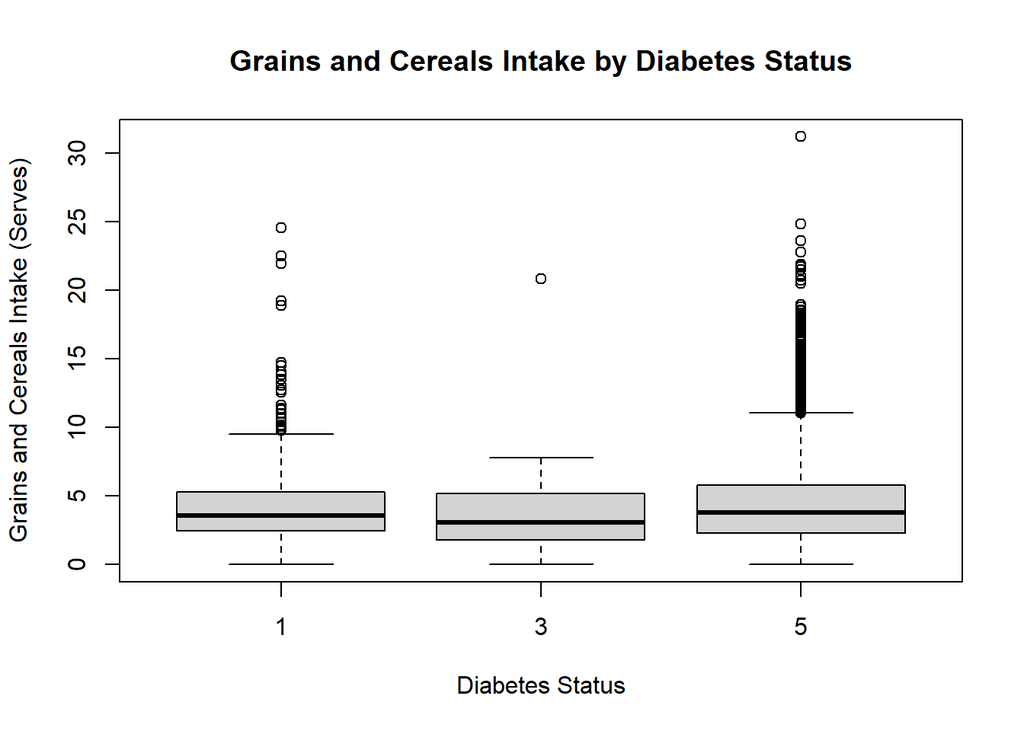

```r
#Boxplot for Question 1
boxplot(GRAINS1N ~ DIABBC, data = merged_data,
        main = "Grains and Cereals Intake by Diabetes Status",
        xlab = "Diabetes Status", ylab = "Grains and Cereals Intake (Serves)")
```

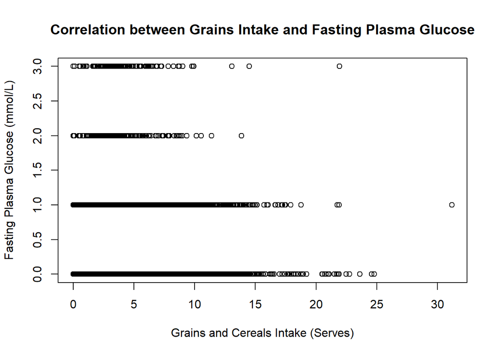

```r
#Scatter Plot for Questions 2 & 3
plot(merged_data$GRAINS1N, merged_data$GLUCFPD,
     main = "Correlation between Grains Intake and Fasting Plasma Glucose",
     xlab = "Grains and Cereals Intake (Serves)", ylab = "Fasting Plasma Glucose (mmol/L)")
```

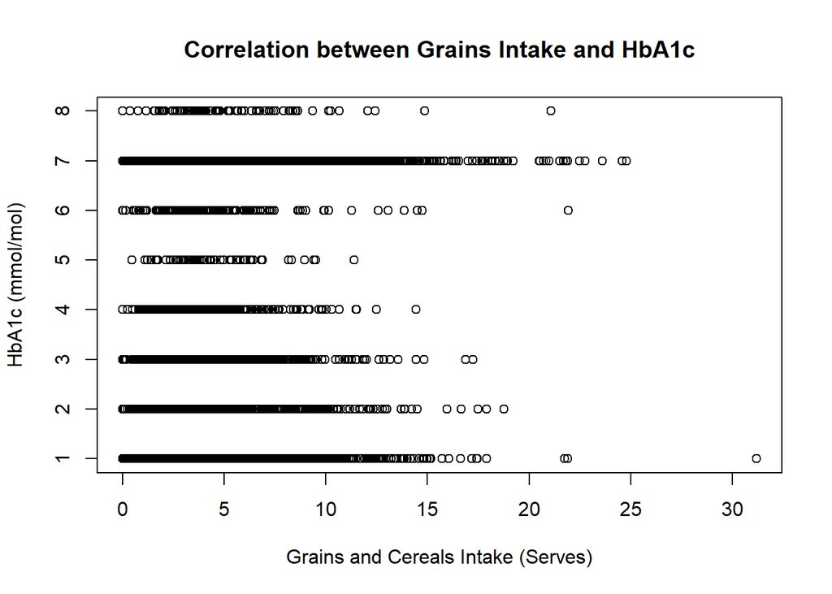

```r
plot(merged_data$GRAINS1N, merged_data$HBA1MREB,
     main = "Correlation between Grains Intake and HbA1c",
     xlab = "Grains and Cereals Intake (Serves)", ylab = "HbA1c (mmol/mol)")
```

# What’s Next ## 1. Further Analysis and Model Building: • Logistic Regression (for Question 1): o Use logistic regression to model the probability of diabetes as a function of grains and cereals intake, controlling for confounding variables.

• Linear Regression (for Questions 2 & 3): o Use linear regression to model the relationship between grains and cereals intake and fasting plasma glucose/HbA1c.

## 2. Addressing Potential Confounders:

• Perform sensitivity analysis to check the robustness of your findings against potential confounders. • Consider stratification or matching if confounding is severe. ## 3. Statistical Methods to Consider: • Logistic Regression: To examine the dependence of categorical outcomes (like diabetes status) on predictors. • Linear Regression: To model the relationship between continuous outcomes (like glucose levels, HbA1c) and predictors. • ANOVA: To test for significant differences in means across multiple groups, especially if you expand to include more dietary categories. • Multivariate Analysis: If you plan to examine multiple outcomes simultaneously. ## 4. Data Cleaning and Preparation: • Handle missing data using imputation or complete case analysis. • Standardize or normalize variables if needed, particularly for biomarkers with different scales. ## 5. Final Analysis and Reporting: • Conduct the final statistical analysis using the models outlined above. • Interpret the results, highlighting significant findings and their implications. • Prepare visualizations that effectively communicate your results.

```r
# Save the summary table as a CSV file
#write.csv(variable_info, file = "variable_info_summary.csv", row.names = FALSE)
```